# Final project: ARIMAX Model for Gasoline Consumption

```r
par(mfrow=c(1,1))
```

We see that the model $ARIMA(0,1,1)(0,1,1)_{12}$ is still consistent with the ACF/PACF structure of the linearized series, so we fit it, taking into account also the calendar effects:

```r
(mod.lin=arima(lnserie.lin,order=c(0,1,1),seasonal=list(order=c(0,1,1),period=12), xreg=data.frame(wTradDays,wEast)))
```

```
##
## Call:
## arima(x = lnserie.lin, order = c(0, 1, 1), seasonal = list(order = c(0, 1, 1),
##     period = 12), xreg = data.frame(wTradDays, wEast))
##
## Coefficients:
##           ma1     sma1  wTradDays   wEast
##       -0.6820  -0.7465     0.0042  0.0350
## s.e.   0.0373   0.0506     0.0003  0.0048
##
## sigma^2 estimated as 0.0004146:  log likelihood = 764.56,  aic = -1519.12
```

Finally, we have to validate this model:

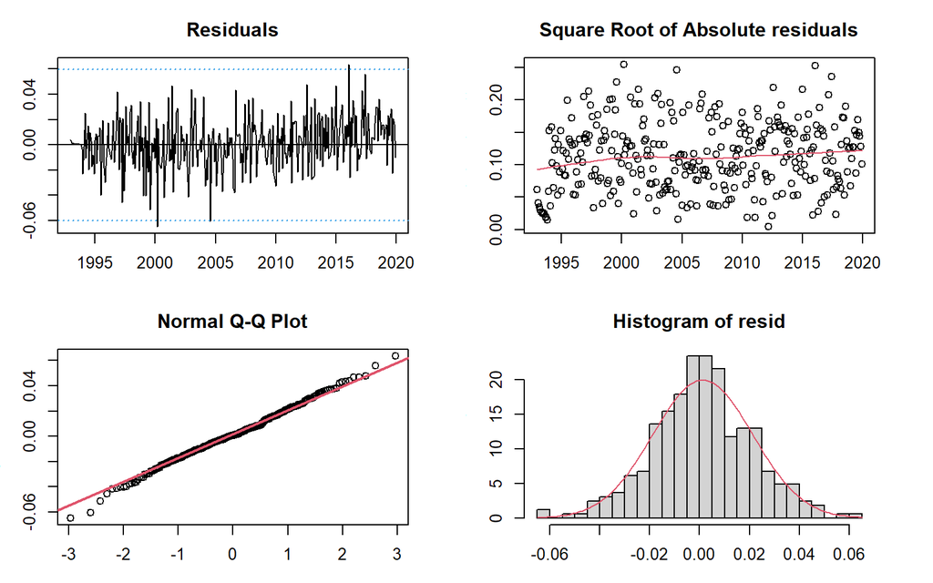

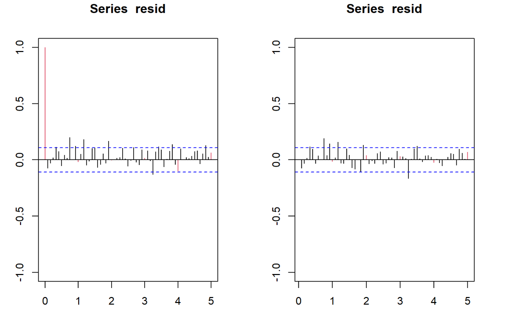

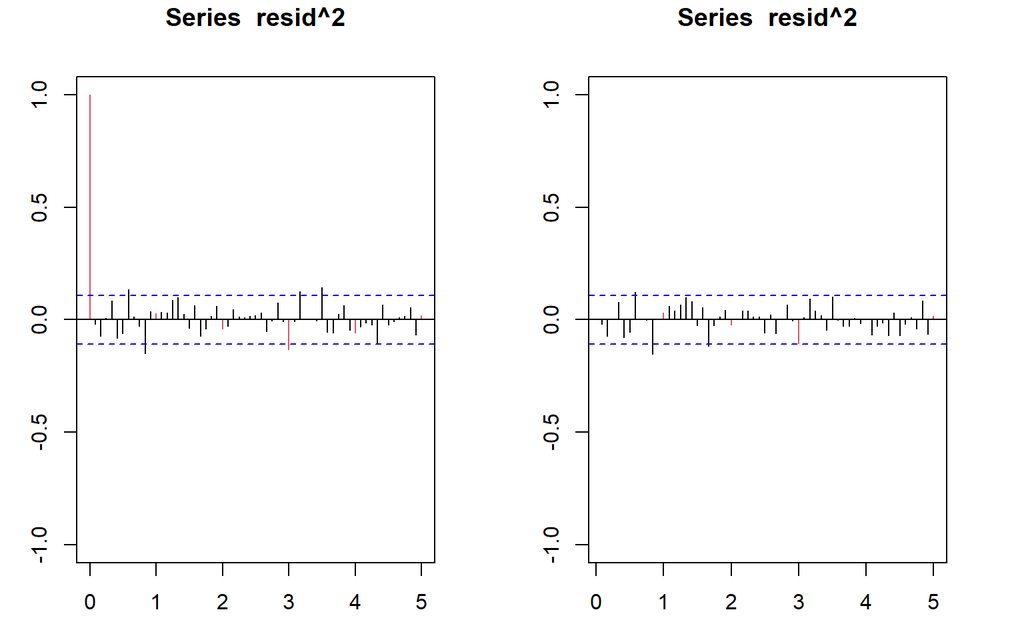

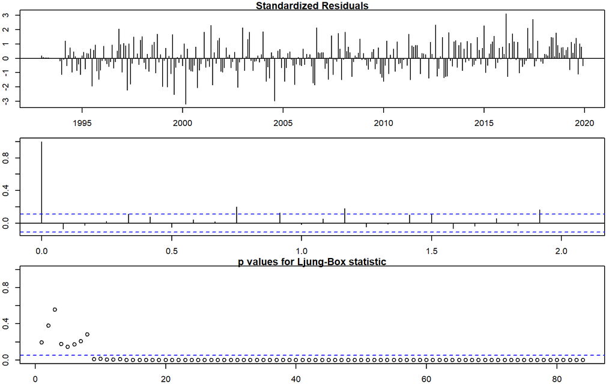

```
##
## --------------------------------------------------------------------
##
## Call:
## arima(x = lnserie.lin, order = c(0, 1, 1), seasonal = list(order = c(0, 1, 1),
##     period = 12), xreg = data.frame(wTradDays, wEast))
##
## Coefficients:
##           ma1     sma1  wTradDays   wEast
##       -0.6820  -0.7465     0.0042  0.0350
## s.e.   0.0373   0.0506     0.0003  0.0048
##
## sigma^2 estimated as 0.0004146:  log likelihood = 764.56,  aic = -1519.12
##
## Modul of AR Characteristic polynomial Roots:
##
## Modul of MA Characteristic polynomial Roots:  1.024666 1.024666 1.024666 1.024666 1.024666 1.024666 1.024666 1.024666 1.024666 1.024666 1.024666 1.024666 1.466206
##
## Psi-weights (MA(inf))
##
## --------------------
##      psi 1      psi 2      psi 3      psi 4      psi 5      psi 6      psi 7
## -0.6820325  0.0000000  0.0000000  0.0000000  0.0000000  0.0000000  0.0000000
##      psi 8      psi 9     psi 10     psi 11     psi 12     psi 13     psi 14
##  0.0000000  0.0000000  0.0000000  0.0000000 -0.7464719  0.5091181  0.0000000
##     psi 15     psi 16     psi 17     psi 18     psi 19     psi 20
##  0.0000000  0.0000000  0.0000000  0.0000000  0.0000000  0.0000000
##
## Pi-weights (AR(inf))
##
## --------------------
##        pi 1        pi 2        pi 3        pi 4        pi 5        pi 6
## -0.68203252 -0.46516836 -0.31725995 -0.21638161 -0.14757929 -0.10065388
##        pi 7        pi 8        pi 9       pi 10       pi 11       pi 12
## -0.06864922 -0.04682100 -0.03193344 -0.02177965 -0.01485443 -0.75660314
##       pi 13       pi 14       pi 15       pi 16       pi 17       pi 18
## -0.51602795 -0.35194784 -0.24003988 -0.16371500 -0.11165896 -0.07615504
##       pi 19       pi 20
## -0.05194021 -0.03542492
##
```

[output cut: 38 more lines]

```
## data:  resid(model) ~ I(1:length(resid(model)))
## DW = 2.2235, p-value = 0.9751
## alternative hypothesis: true autocorrelation is greater than 0
##
##
## Ljung-Box test
##      lag.df  statistic      p.value
## [1,]      1   1.703314 1.918552e-01
## [2,]      2   1.936665 3.797157e-01
## [3,]      3   2.074972 5.569927e-01
## [4,]      4   6.302733 1.776520e-01
## [5,]     12  28.273894 5.043534e-03
## [6,]     24  61.844433 3.491243e-05
## [7,]     36  75.610029 1.240551e-04
## [8,]     48 109.404514 1.078234e-06
```

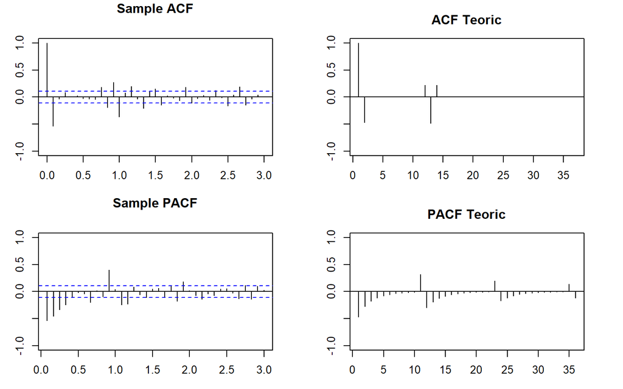

```r
dades=d1d12lnserie.lin
model=mod.lin
validation(model,dades)
```

With respect to the original model we see that:

- The heavy tails have almost been eliminated and now all the normality tests say that the residuals are normally distributed.
- The ACF/PACF structure of the square of the residuals is now way better than in the original case (the first lags are all almost null), so there is a better homogeneity of the variance.
- The independence of residuals is not being achieved either.
- As before, the model is causal and invertible.
- The theoretical and sample ACF/PACF structure are very similar. Goodness of fit measures: log-likelihood is 764.56, AIC is -1519.12 and $\sigma^2 = 0.0004146$.

Despite not achieving all the assumptions of an ARIMA model, we will consider this linearized model as good and we will take it as our final model.

## Forecasting

With the last fitted linearlized model, we will once again perform predictions and compare them to the ones made with the classical ARIMA model. As before, we will first check the stability of the model:

```r
ultim = c(2018,12)
pdq_1 = c(0,1,1)
PDQ = c(0,1,1)

serie2=window(lnserie.lin,end=ultim)
serie1=window(lnserie.lin,end=ultim+c(1,0))

wTradDays2=window(wTradDays,end=ultim)
wEast2=window(wEast,end=ultim)
```

```r
(mod.linA=arima(serie1,order=pdq_1,seasonal=list(order=PDQ,period=12), xreg=data.frame(wTradDays,wEast)))
```

```
##
## Call:
## arima(x = serie1, order = pdq_1, seasonal = list(order = PDQ, period = 12),
##     xreg = data.frame(wTradDays, wEast))
##
## Coefficients:
##           ma1     sma1  wTradDays   wEast
##       -0.6820  -0.7465     0.0042  0.0350
## s.e.   0.0373   0.0506     0.0003  0.0048
##
## sigma^2 estimated as 0.0004146:  log likelihood = 764.56,  aic = -1519.12
```

```r
(mod.linB=arima(serie2,order=pdq_1,seasonal=list(order=PDQ,period=12), xreg=data.frame(wTradDays2,wEast2)))
```

```
##
## Call:
## arima(x = serie2, order = pdq_1, seasonal = list(order = PDQ, period = 12),
##     xreg = data.frame(wTradDays2, wEast2))
##
## Coefficients:
##           ma1     sma1  wTradDays2  wEast2
##       -0.6853  -0.7585      0.0042  0.0363
## s.e.   0.0379   0.0521      0.0003  0.0050
##
## sigma^2 estimated as 0.0004175:  log likelihood = 733.58,  aic = -1457.16
```

We clearly see stability of the model (magnitude, sign and significance of coefficients). We will first perform predictions on the known data to compare the prediction results with the ones obtained for the original model:

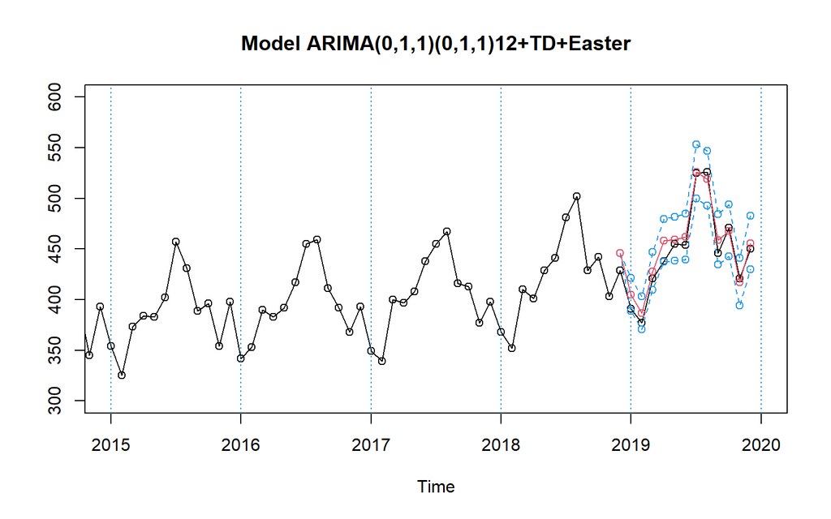

```r
pred=predict(mod.linB,n.ahead=12,newxreg=window(cbind(wTradDays,wEast),start=c(ultim[1]+1,1)))
predic=pred$pr
pr.lin<-ts(c(tail(serie2,1),predic),start=ultim,freq=12)
se.lin<-ts(c(0,pred$se),start=ultim,freq=12)

#Intervals
tl.lin<-ts(exp(pr.lin-1.96*se.lin),start=ultim,freq=12)
tu.lin<-ts(exp(pr.lin+1.96*se.lin),start=ultim,freq=12)
pr.lin<-ts(exp(pr.lin),start=ultim,freq=12)

ts.plot(serie,tl.lin,tu.lin,pr.lin,lty=c(1,2,2,1),col=c(1,4,4,2),xlim=ultim[1]+c(-3,2),type="o",main="Model ARIMA(0,1,1)(0,1,1)12+TD+Easter", ylim=c(300,600))
abline(v=(ultim[1]-3):(ultim[1]+2),lty=3,col=4)
```

With a first glance, we can already see that predictions seem better. We will check the metrics:

```r
obs=window(serie,start=ultim)

mod.RMSE=sqrt(sum((obs-pr.lin)^2)/12)
mod.MAE=sum(abs(obs-pr.lin))/12
mod.RMSPE=sqrt(sum(((obs-pr.lin)/obs)^2)/12)
mod.MAPE=sum(abs(obs-pr.lin)/obs)/12
mod.ML=sum(tu.lin-tl.lin)/12

metrics_lin <- data.frame("Model"=paste("ARIMA(",paste(pdq_1,collapse=","),")(",paste(PDQ,collapse=","),")12 + CE + atipics",sep=""),"RMSE"=mod.RMSE,"MAE"=mod.MAE,"RMSPE"=mod.RMSPE,"MAPE"=mod.MAPE,"Mean length"=mod.ML)

metrics <- rbind(metrics1, metrics_lin)
metrics
```

```
##                                  Model     RMSE       MAE      RMSPE       MAPE
## 1                ARIMA(0,1,1)(0,1,1)12 26.30145 22.798900 0.05549803 0.04915055
## 2 ARIMA(0,1,1)(0,1,1)12 + CE + atipics 10.67068  9.380336 0.02496546 0.02173510
##   Mean.length
## 1    68.35688
## 2    45.07661
```

We confirm that the predictions are way better now, substantially lowering all the performance metrics.

Now, just for completion, we will plot the long-term predictions of both the original model and the one corrected with calendar effects and outliers treatment (we will have to predict again the original ones as we did not do the original predictions with the model we ended up using):

```r
pred=predict(mod1A,n.ahead=12)
pr<-ts(c(tail(lnserie,1),pred$pred),start=ultim+c(1,0),freq=12)
se<-ts(c(0,pred$se),start=ultim+c(1,0),freq=12)

#Intervals
tl<-ts(exp(pr-1.96*se),start=ultim+c(1,0),freq=12)
tu<-ts(exp(pr+1.96*se),start=ultim+c(1,0),freq=12)
pr<-ts(exp(pr),start=ultim+c(1,0),freq=12)
```

```r
pred=predict(mod.linA,n.ahead=12,newxreg=window(cbind(wTradDays,wEast)))
pr.lin<-ts(c(tail(lnserie,1),pred$pred),start=ultim+c(1,0),freq=12)
se.lin<-ts(c(0,pred$se),start=ultim+c(1,0),freq=12)

#Intervals
tl.lin<-ts(exp(pr.lin-1.96*se.lin),start=ultim+c(1,0),freq=12)
tu.lin<-ts(exp(pr.lin+1.96*se.lin),start=ultim+c(1,0),freq=12)
pr.lin<-ts(exp(pr.lin),start=ultim+c(1,0),freq=12)
```

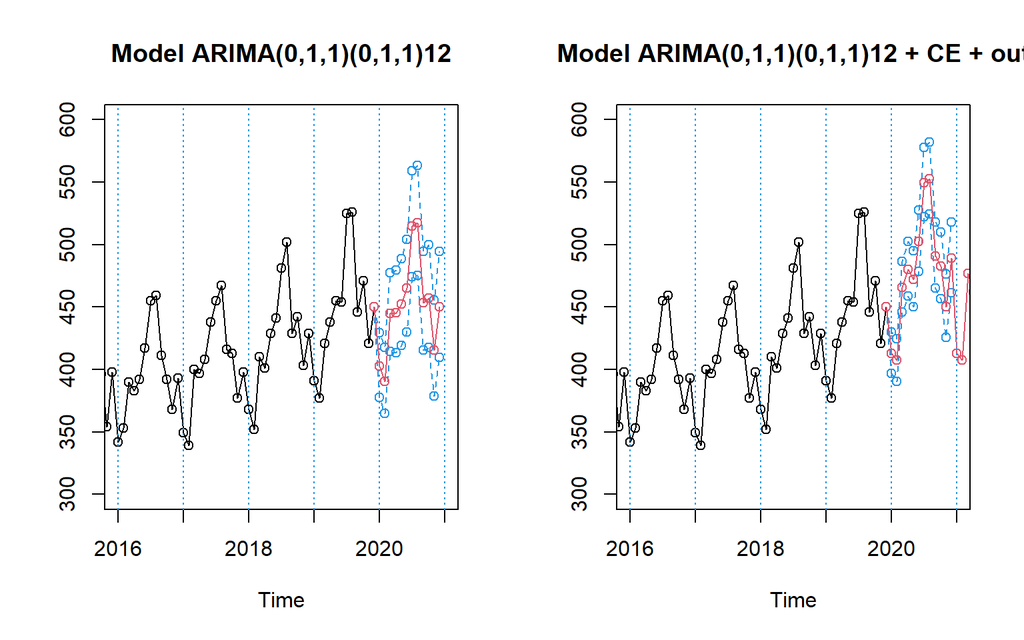

```r
par(mfrow=c(1,2))
ts.plot(serie,tl,tu,pr,lty=c(1,2,2,1),col=c(1,4,4,2),xlim=c(ultim[1]-2,ultim[1]+3),type="o",main="Model ARIMA(0,1,1)(0,1,1)12",ylim=c(300,600))
abline(v=(ultim[1]-2):(ultim[1]+3),lty=3,col=4)
ts.plot(serie,tl.lin,tu.lin,pr.lin,lty=c(1,2,2,1),col=c(1,4,4,2),xlim=c(ultim[1]-2,ultim[1]+3),type="o",main="Model ARIMA(0,1,1)(0,1,1)12 + CE + out",ylim=c(300,600))
abline(v=(ultim[1]-2):(ultim[1]+3),lty=3,col=4)
```

In conclusion, the two graphs presented above clearly illustrate the significant impact of treating calendar effects and outliers in the gasoline dataset. By applying appropriate adjustments to account for these factors, we are able to enhance the accuracy and reliability of our predictions.

# Conclusions

During this assignment, we have been able to review all the concepts that we have learned during the first part of the course. We have treated and analyzed a real time series while applying the techniques that were explained during the lectures.

After putting the series as stationary and finding suitable models, we have had to treat calendar effects and outliers. We have seen that in real time series, we do not always get perfect ARIMA models, as it was the case: the final model did not fulfill all the assumptions of an ARIMA model, but we had to accept it as valid, since we did not have more information about other possible calendar effects or outliers to treat.

However, we have seen that the linearized version of the model (taking into account calendar effects and outliers) performed substantially better when doing predictions.

We conclude that when treating real series, we will not always be able to find the perfect theoretical model, but we still have to find the best one with the information and tools we have.